# Lab_3

## Optimizing Exclusion of Data Due to Error

```python
import numpy as np
import matplotlib
import matplotlib.pyplot as plt
import scipy
from scipy import stats
import pandas as pd
```

In an experiment that is reliant on a fairly consistent and specific temperature, it is important to be able to discover possible data points in which the thermal control system or the thermometry operated incorrectly and returned measurements that are not appropriate for inclusion in the analysis.

Suppose we conducted an experiment and we needed to maintain a temperature of 12 K, with a precision (or standard deviation) of 0.4. If we assume Gaussian fluctuation, we can make a model of our expected data set in the form of a random Gaussian distribution centered around 12 with a 0.4 sigma.

In order to model the possible misbehavior of our experimental equipment, we make a set of "bad data" to include with the original distribution. This sets up the problem that we may be faced with in a real experiment: how do we get rid of the maximum amount of bad data while retaining the maximum amount of good data in our dataset?

In a real experiment, we would not necessarily know right away which data are good or bad; we might be able to guess at some points on the extremes of our dataset that really stick out, but as they get closer to what we would consider to be expected values, that distinction between good and bad gets a little blurred, as the bad is interspersed amongst the good.

Another way to state this dilemma would be to say, if we reduce our dataset to within N standard deviations, which value for N will leave us with the most original ("good") data and the least data that resulted from misbehavior of the experimental setup ("bad data")?

Below is a histogram of the combination of the Gaussian distributed dataset we made plus the set of bad data.

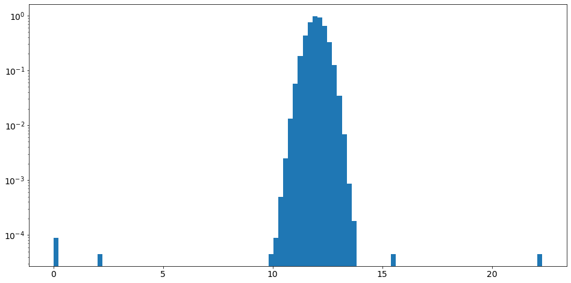

```python
plt.rcParams["figure.figsize"] = (16,8)

d = np.append(stats.norm.rvs(loc = 12., scale = 0.4, size = 100000), [10., 10.3, 2.1, 0., 0., 15.6, 22.3, 12.7])
fig, ax = plt.subplots(1, 1)
ax.hist(d,100, density=True)
plt.tick_params(labelsize = 14)
plt.yscale('log')
plt.show()
```

In order to check that we do indeed have a Gaussian distribution, and also to maybe see where we can establish a reasonable cut-off value, we can use a logplot to look at the shape of the data and see how well it conforms to a typical Gaussian distribution with the same deviation value.

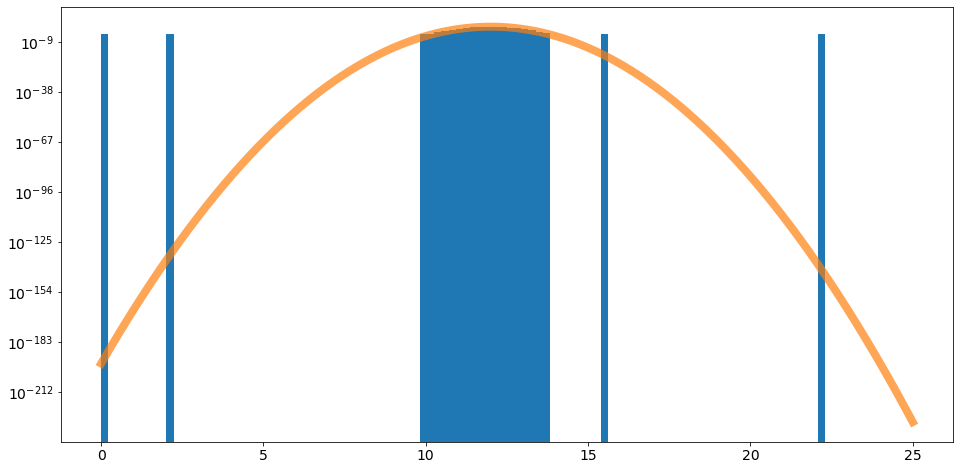

```python
fig, ax = plt.subplots(1, 1)
ax.hist(d,100, density=True)
plt.tick_params(labelsize = 14)
plt.yscale('log')
x = np.linspace(0,25,100000)
ax.plot(x,stats.norm.pdf(x,loc = 12., scale = 0.4),linewidth = 8,alpha = 0.7)
plt.show()
```

As we can see from above, the data generally follows the Gaussian log curve very well, but there are four datapoints that absolutely stand out, as well as a fifth that looks like it is probably not a good datum but is not quite as glaring as the others. However, because we made the bad data ourselves, we know that there are eight bad data points, so cutting out the data points which we can see don't fit will not be enough.

To examine this further, it will be helpful to know where different multiples of standard deviations occur in our dataset. First, we can check that the stated standard deviation of 0.4 really does return a value of 1 sigma. We can do this by calculating the probability associated with $T=12\pm{0.4}$, and using that probability in combination with the inverse survival function to determine the value of sigma.

```python
Px1 = stats.norm.sf(12.4, loc=12., scale=0.4)
Px2 = stats.norm.cdf(11.6, loc=12., scale=0.4)
print(Px1,Px2)
```

```
0.15865525393145685 0.15865525393145685
```

```python
sigma = stats.norm.isf(Px1, loc=0, scale=1)
print(sigma)
```

```
1.0000000000000007
```

Doing the math gave us results confirming that our distribution has the right parameters.

Now, since 5 sigma is the boundary at which statistical significance of a signal versus a background or noise occurs, we can use that as an outer limit for what we consider necessary data. In other words, our original "good" dataset should not have any large amplitudes occurring at or greater than 5 sigma. If larger values show up in those regions, we can be reasonably sure they are due to misbehavior and should not be included in the final analysis.

To find what temperatures in our dataset correspond to 5 sigma, we calculate the probability of a 5 sigma measurement in a normal distribution and using that probability in combination with the inverse survival function and the percent point function in order to get both temperature values that correspond with 5 sigma.

```python
P5_1 = stats.norm.sf(5, loc=0, scale=1)
P5_2 = stats.norm.sf(-5, loc=0, scale=1)
print(P5_1,P5_2)
```

```
2.866515718791933e-07 0.9999997133484281
```

```python
x5 = stats.norm.isf(P5_1, loc=12., scale=0.4)
print(x5)
```

```
14.0
```

```python
x6 = stats.norm.ppf(P5_1, loc=12., scale=0.4)
print(x6)
```

```
10.0
```

Additionally, we can calculate other values of sigma using the same process, and use them to figure out which cutoff point is best.

```python
P4_1 = stats.norm.sf(4, loc=0, scale=1)
P4_2 = stats.norm.sf(-4, loc=0, scale=1)
print(P4_1,P4_2)
```

```
3.167124183311986e-05 0.9999683287581669
```

```python
x7 = stats.norm.isf(P4_1, loc=12., scale=0.4)
print(x7)
x8 = stats.norm.ppf(P4_1, loc=12., scale=0.4)
print(x8)
```

```
13.600000000000001
10.399999999999999
```

```python
P3_1 = stats.norm.sf(3, loc=0, scale=1)
P3_2 = stats.norm.sf(-3, loc=0, scale=1)
print(P3_1,P3_2)
```

```
0.0013498980316300933 0.9986501019683699
```

```python
x9 = stats.norm.isf(P3_1, loc=12., scale=0.4)
print(x9)
x10 = stats.norm.ppf(P3_1, loc=12., scale=0.4)
print(x10)
```

```
13.2
10.8
```

```python
P2 = stats.norm.sf(2, loc=0, scale=1)
print(P2)
```

```
0.022750131948179195
```

```python
x11 = stats.norm.isf(P2, loc=12., scale=0.4)
print(x11)
x12 = stats.norm.ppf(P2, loc=12., scale=0.4)
print(x12)
```

```
12.8
11.2
```

Below is a logplot of the dataset along with a Gaussian distribution curve and color-coded vertical lines indicating where each different temperature corresponding to N sigma occurs for N equal to one through five.

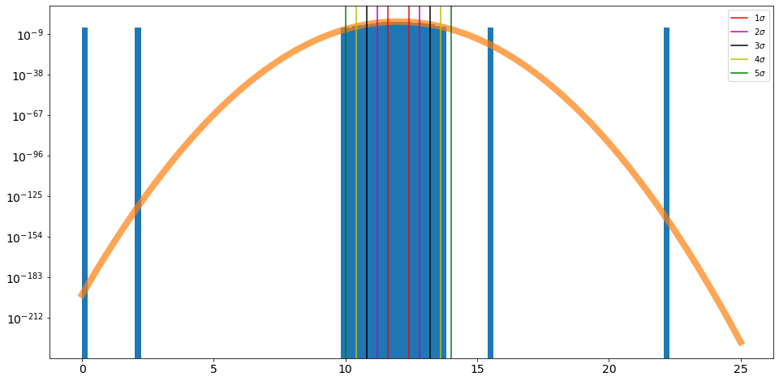

```python
fig, ax = plt.subplots(1, 1)
ax.hist(d,100, density=True)
plt.tick_params(labelsize = 14)
plt.yscale('log')
x = np.linspace(0,25,100000)
ax.plot(x,stats.norm.pdf(x,loc = 12., scale = 0.4),linewidth = 8,alpha = 0.7)
plt.axvline(x=11.6, color='r', label='1'r'$\sigma$')
plt.axvline(x=12.4, color='r')
plt.axvline(x=12.8, color='m', label='2'r'$\sigma$')
plt.axvline(x=11.2, color='m')
plt.axvline(x=13.2, color='k', label='3'r'$\sigma$')
plt.axvline(x=10.8, color='k')
plt.axvline(x=13.6, color='y', label='4'r'$\sigma$')
plt.axvline(x=10.4, color='y')
plt.axvline(x=14.0, color='g', label='5'r'$\sigma$')
plt.axvline(x=10.0, color='g')
plt.legend()
plt.show()
```

As we can see from the plot above, using the 5 sigma cut-off will leave all of the original data, but it will also include three of the bad data points in the dataset. Depending on the size and sensitivity of our experimental results, as well as the magnitude of the bad data points, this may or may not be a problem.

Each sigma value less than 5 will cut off some of the original data, but will also exclude more bad data than the 5 sigma cut-off.

With this in mind, a 1 sigma cut off is likely to exclude all or nearly all bad data, but it will also cut out a substantial portion of our good dataset, and therefore it is not a good candidate for the cut-off. For the same reason, 2 sigma is not a good candidate, as it would remove a significant amount of the original dataset (approximately 4%). Numerically, that removal would make a much bigger difference in the calculated results of our experiment than the inclusion of a small number of bad data points that are indistinguishable from the rest of the data.

We can compare the different cutoffs of 3, 4, and 5 sigma in terms of the number of original data preserved, bad data excluded, bad data included, and good data excluded by making truth tables for each cutoff.

```python
err = np.array([10.,10.3,2.1,0.,0.,15.6,22.3,12.7])

err_3 = 0
err_4 = 0
err_5 = 0

for i in range(0,8):
    if err[i]>=10.8 and err[i]<=13.2:
        err_3 = err_3 + 1
    else:
        err_3 = err_3
    if err[i]>=10.4 and err[i]<=13.6:
        err_4 = err_4 + 1
    else:
        err_4 = err_4
    if err[i]>=10. and err[i]<=14.:
        err_5 = err_5 + 1
    else:
        err_5 = err_5
print(err_3,err_4,err_5)
```

```
1 1 3
```

```python
size_5 = 0
size_4 = 0
size_3 = 0
size_2 = 0
size_1 = 0

for j in range(0,d.size):
    if d[j]>=10. and d[j]<=14.:
        size_5 = size_5 + 1
    else:
        size_5 = size_5
    if d[j]>=10.4 and d[j]<=13.6:
        size_4 = size_4 + 1
    else:
        size_4 = size_4
    if d[j]>=10.8 and d[j]<=13.2:
        size_3 = size_3 + 1
    else:
        size_3 = size_3
    if d[j]>=11.2 and d[j]<=12.8:
        size_2 = size_2 + 1
    else:
        size_2 = size_2
    if d[j]>=11.6 and d[j]<=12.4:
        size_1 = size_1 + 1
    else:
        size_1 = size_1
print(size_1,',',size_2,',',size_3,',',size_4,',',size_5)
```

```
68472 , 95522 , 99735 , 99992 , 100003
```

```python
data_3 = {'True T': [size_3 - err_3, 100000 - size_3 - err_3],
        'Bad T': [8 - err_3, err_3]
        }

df_3 = pd.DataFrame(data_3, index=['Our Test Good','Our Test Bad'])
df_3 = df_3.astype({"True T": int, "Bad T": int})

data_4 = {'True T': [size_4 - err_4, 100000 - size_4 - err_4],
        'Bad T': [8 - err_4, err_4]
        }

df_4 = pd.DataFrame(data_4, index=['Our Test Good','Our Test Bad'])
df_4 = df_4.astype({"True T": int, "Bad T": int})

data_5 = {'True T': [size_5 - err_5, 100000 - size_5 + err_5],
        'Bad T': [8 - err_5, err_5]
        }

df_5 = pd.DataFrame(data_5, index=['Our Test Good','Our Test Bad'])
df_5 = df_5.astype({"True T": int, "Bad T": int})

df_3
```

|  | True T | Bad T |
| --- | --- | --- |
| Our Test Good | 99734 | 7 |
| Our Test Bad | 264 | 1 |

As shown above, the 3 sigma cut-off is able to eliminate all but one bad data point. However, in the process, it cuts out 0.3% of our data. This is not an optimal solution, since it does not improve on the exclusion of bad data points from that of the 4 sigma cut-off, as shown below.

```python
df_4
```

|  | True T | Bad T |
| --- | --- | --- |
| Our Test Good | 99991 | 7 |
| Our Test Bad | 7 | 1 |

```python
df_5
```

|  | True T | Bad T |
| --- | --- | --- |
| Our Test Good | 100000 | 5 |
| Our Test Bad | 0 | 3 |

The size of our dataset makes a big difference to how we view this problem. Since we have an original dataset of 100k points plus 8 bad data points, the exclusion of only those data points outside of the 5 sigma cut-off would likely give us pretty reasonable results, because those bad points would have the largest effect on our results. Since all other bad data points fall within the regular Gaussian distribution we would expect, they might not make a great difference in our analysis of the variable we care about in the experiment.

If we take the ratio of bad data points to data points total, we find that both situations give a ratio of the same order of magnitude, but the ratio for 5 sigma is approximately 3 times that of 4 sigma.

```python
r4 = err_4/(size_4)
r5 = err_5/(size_5)
print(r4,',',r5)
```

```
1.000080006400512e-05 , 2.999910002699919e-05
```

Therefore, it matters what we are measuring or looking for, and it matters how dramatic the error is in the context of the experiment, but in general the 4 sigma cut-off seems the optimal choice.

As our truth tables show, the number of omissions of good data points with each lower sigma-value cut-off is a predictable quantity that depends on the size and shape of your dataset. Though the breadth of the distribution of data may differ between datasets, if they have a known distribution we can calculate how many points will be lost with each successive cut-off.

Because the bad data set was interspersed with the good data of the background, there was one unavoidable mistake of commission. In order to avoid that mistake, we would have had to cut the data off at the 1 sigma boundaries, which would have reduced our dataset by nearly a third. It is much better to include the one bad point than to exclude almost 32,000 good data points.

However, if the bad data had occurred in a recognizable pattern, especially if we knew that pattern beforehand (from instrument specifications, Johnson noise, etc.), we could remove that pattern specifically from the dataset with minimal issues. Since the bad dataset we created does not follow a particular pattern, however, the inclusion of some bad data is unavoidable as it is unrecognizable from the good data (unless we cheat and just remove the points we put in).

In some ways, this depends on our chosen statistical threshold, and in some ways it doesn't. For instance, there is a difference between the errors included between the 5 and 4 sigma thresholds, and there is difference between 2 and 1. However, the number of bad data points that get in is the same for 2,3, and 4. This suggests that it depends highly on the distribution of our bad data; if the bad data were evenly distributed over the background, we would see a clear relationship, but if it is random or weighted toward the extremes, we might not see a clear dependence.

## Judging Statistical Significance in Two-Dimensional Distributions

Suppose we are looking in the night sky for the movement of bright objects (such as asteroids) while dealing with 2D distributions of positional uncertainty due to instrumental and atmospheric effects on the data we are able to record.

In order to be able to say confidently that we have measured what we consider to be a movement, we need to have measured a relatively bright amplitude at a distance in arcseconds far enough away from the center (where the mean of both axes of the 2D distribution occurs) that it has a low enough probability of being produced by the background distribution that we can consider a signal measurement.

Below is a plot of the 2D Gaussian distribution we are considering.

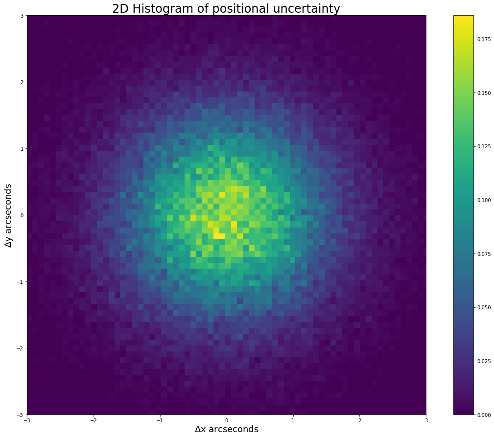

```python
plt.rcParams["figure.figsize"] = (20,15)
a = np.vstack((stats.norm.rvs(loc=0, scale = 1, size = 100000), stats.norm.rvs(loc=0, scale = 1, size = 100000)))
a.shape
fig, ax = plt.subplots(1, 1)
h = ax.hist2d(a[0,:],a[1,:],bins=100, density=True);
ax.set_aspect('equal', 'box')
plt.xlim([-3 , 3])
plt.ylim([-3 , 3])
plt.title("2D Histogram of positional uncertainty", fontsize = 24)
plt.ylabel("$\Delta$y arcseconds", fontsize = 18)
plt.xlabel("$\Delta$x arcseconds", fontsize = 18)
plt.colorbar(h[3], ax=ax)
```

In order to find a movement that would be considered statiscally significant enough that it would be reasonable enough for us to consider it as not due to the movement of the starlight inherent in our measurement, we need to make sure that the signal we see is occuring far enough away from the center of the image that it could be considered a 5 sigma detection. This means that the distance of the signal we see from the center of the distribution must be large anough that it cannot be attributed to the background provided by the star.

So, a question we could ask would be something like: What magnitude of distance in arcseconds must there be between our candidate measurement and the center of the distribution due to starlight in order for us to conclude that it has a low enough probability of being produced by the distortion of the star's light that we can consider it as a possible signal indicating the movement of the asteroid?

Since our two-dimensional background distribution is produced by the sum of two independent Gaussian distributions ($X$ and $Y$), we can represent the 2D distribution with a Rayleigh distribution of two independent variables:

$f_{X+Y} = \frac{\sqrt{x^2+y^2}}{\sigma_{x}^2+\sigma_{y}^2} e^{-\frac{x^2+y^2}{2(\sigma_{x}^2+\sigma_{y}^2)}} = \sqrt{x^2+y^2} e^{-\frac{x^2+y^2}{2}}$

We can simplify the equation (as above right) since both distributions have the same width. We can further simplify it by combining the two independent variables into a single variable whose magnitude would represent the radius of a circle drawn around the center of the 2D distribution. That radius is the variable we can use as our measure for the required distance from the center of the distribution in order to claim statistical significance.

$f_{X+Y} = r e^{-\frac{r^2}{2}}$

First we determine the probability at which a 5 sigma measurement would occur, then use it to find the corresponding value of the distance.

```python
P_r = stats.norm.sf(5, loc=0, scale=1)
r = stats.rayleigh.isf(P_r, loc=0, scale=1)
print(r)
```

```
5.489079776062419
```

Therefore, in order for us to be able to say we have a signal-like candidate for motion, there must be a difference in distance of approximately 5.4891 arcseconds.

## Judging Statistical Significance

Suppose we are measuring the occurrence of incoming cosmic rays over a period of 8 hours for 15 days in a row. If we are looking at a patch of sky (with no obstructions) that is the size of the Moon, and the rate that we measure incoming cosmic rays at is one ray per minute, this gives us a background distribution of cosmic rays by which we can judge how statistically different the measurements of incoming cosmic rays we receive is when we actually look at the Moon. By looking at our dataset, we can judge whether or not our measurements approach something signal=like in which we see a great enough difference that we could reasonably expect that there is an obstruction present (the Moon). So, our question could be something like:

Given the difference between the data we have measured and the cosmic ray background distribution we expect, does our data occur with a low enough probability that we can reasonably say it is a signal rather than the result of the cosmic ray background?

```python
t = 7200 # in minutes
rate = 1 # in rays per minute
mu = rate*t # average detections
k = 6800 # actual detections
```

Our background distribution can be represented using a Poisson distribution with a mean equal to the average rate of detection multiplied by the duration time of our data collection. In order to find the probability of our measurement occurring as a result of the background distribution, we use a cumulative distribution function to integrate from our measured value $k$ to $-\infty$, because $k$ is less than the average detection we would expect from our background distribution. Then we use that probability to determine the standard deviation of our measurement from the detection that we would expect.

```python
P_k = stats.poisson.cdf(k, mu, loc=0)
print(P_k)
```

```
1.0133280183917768e-06
```

```python
sigma_k = stats.norm.isf(P_k, loc=0, scale=1)
print(sigma_k)
```

```
4.750747965777188
```

Since we have calculated our sigma to be approximately 4.75, though we have not quite hit the 5-sigma mark we would want in order to be certain that a large object (such as the Moon) exists in the region from which we took our measurements, we have gotten quite close. This is an indication that we are very likely correct, but we need to take more data to be sure. As we take more measurements, if we really are seeing a decreased rate of ray detection due to the presence of a large object, then the number of detections we measure will continue to diverge from the number we expect to measure. For instance, if the rate we detect rays stays the same and we were to double the time in which we collect data (and thus double both our expected value and our actual value), we would be able to say very confidently that the area in which we have been measuring is different with statistical significance, and there is indeed likely to be a moon there.

```python
P_k2 = stats.poisson.cdf(2*k, 2*mu, loc=0)
sigma_k2 = stats.norm.isf(P_k2, loc=0, scale=1)
print(sigma_k2)
```

```
6.724220832707354
```